# SupportVectorMachines

```python
import matplotlib.pyplot as plt
import numpy as np
import cvxpy as cp
import tqdm
```

## Support Vector Machines

Consider a set of training data $\{(x_1, y_1), ..., (x_m, y_m)\}$ with inputs $x_i \in \mathbb{R}^n$ for $i \in \{1,...,m\}$ and outputs $y_i \in \{-1, +1\}$ for $i \in \{1,...,m\}$. Using this data, we wish to learn a binary classifier $f : \mathbb{R}^n \rightarrow \{-1, +1\}$ that can predict the correct class label ($-1$ or $+1$) for any provided input vector. A support vector machine (SVM) is a supervised learning technique that can be used to learn such classifiers over both linear and nonlinear datasets.

## Linear Classifiers

### The Hard-Margin SVM

If the training data are linearly seperable, then there must exist two parallel hyperplanes (defined by $w^Tx + b = 1$ and $w^Tx + b = -1$ for some $w \in \mathbb{R}^n$, $b \in \mathbb{R}$) that satisfy the following.

- $w^Tx_i+ b \geq +1$ for all $i \in \{1,...,m\}$ such that $y_i = +1$.
- $w^Tx_i+ b \leq -1$ for all $i \in \{1,...,m\}$ such that $y_i = -1$.

The goal of a hard-margin SVM is to learn the parameters ($w$, $b$) that maximize the the distance between the two hyperplanes (referred to as the *margin*). This distance is given by $\frac{2}{||w||}$. Thus, the optimization problem that we wish to solve is:

$$ \begin{equation} \begin{aligned} \min_{w,b} \quad & ||w|| \\ \text{s.t.} \quad & y_i(w^Tx_i+ b) \geq 1, \quad i \in \{1,...,m\} \\ \end{aligned} \end{equation} $$

After the optimization problem is solved, we have the following classification rule:

$$ \begin{equation} f(x) = \begin{cases} +1 \quad & w^Tx+ b > 0 \\ -1 \quad & w^Tx+ b < 0 \\ \end{cases} \end{equation} $$

The below code generates a linearly seperable dataset, trains the hard-margin SVM by solving the above optimization problem, and produces a visualization of the hyperplanes and margin.

```python
def generate_seperable_dataset(n_samples):
    np.random.seed(seed=0)
    X = np.random.multivariate_normal(
        np.array([0, 0]), np.array([[1, 0], [0, 1]]), n_samples
    )
    X = X[np.where(abs(X[:, 0] - X[:, 1]) > 0.5)]
    y = np.zeros(X.shape[0])
    y[np.where(X[:, 0] - X[:, 1] > 0.5)] = -1
    y[np.where(X[:, 0] - X[:, 1] < -0.5)] = 1
    return X, y


def solve_hard_margin_svm(X, y):
    w, b = cp.Variable(2), cp.Variable(1)
    constraints = [
        y[i] * (X[i, 0] * w[0] + X[i, 1] * w[1] + b) >= 1 for i in range(X.shape[0])
    ]
    prob = cp.Problem(cp.Minimize(cp.norm(w)), constraints)
    result = prob.solve()
    return result, w.value, b.value


def visualize_svm_classifier(X, y, w, b):
    plt.scatter(X[:, 0], X[:, 1], c=y)
    xlim = plt.gca().get_xlim()
    t = [xlim[0], xlim[1]]
    plt.plot(t, [((1 - b) - w[0] * p) / w[1] for p in t], "--")
    plt.plot(t, [((-1 - b) - w[0] * p) / w[1] for p in t], "--")
    plt.plot(t, [(-b - w[0] * p) / w[1] for p in t])
    plt.show()
```

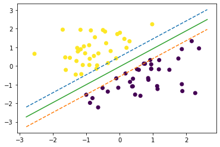

```python
X, y = generate_seperable_dataset(100)
result, w, b = solve_hard_margin_svm(X, y)
visualize_svm_classifier(X, y, w, b)
```

### The Soft-Margin SVM

If the training data are not guaranteed to be linearly seperable, then we can use the hinge loss function to construct our optimization problem. Only samples within the margin contribute to the loss value. Note that $\lambda$ quantifies the relative importance of the two objectives: (1) creating large margins and (2) ensuring that samples are placed on the correct side of the margin boundaries. On seperable data, for sufficiently small $\lambda$, the soft-margin SVM behaves like the hard-margin SVM.

$$ \begin{equation} \begin{aligned} \min_{w,b} \quad & \left[\frac{1}{m}\sum_{i=1}^m \max\left(0, 1 - y_i(w^Tx_i+ b)\right)\right] + \lambda ||w|| \\ \end{aligned} \end{equation} $$

We can reformulae the hinge loss optimization problem as a quadratic program. We do this by introducing non-negative slack variables $\zeta_i$ for $i \in \{1,...,m\}$ as below. Non-zero slack variables represent training examples that fall inside the margin.

$$ \begin{equation} \begin{aligned} \min_{w,b,\zeta} \quad & \frac{1}{m}\sum_{i=1}^m \zeta_i + \lambda||w|| \\ \text{s.t.} \quad & y_i(w^Tx_i+ b) \geq 1 - \zeta_i, \quad i \in \{1,...,m\} \\ & \zeta_i \geq 0, \quad i \in \{1,...,m\} \\ \end{aligned} \end{equation} $$

The below code generates a non-seperable dataset, trains the soft-margin SVM by solving the above optimization problem, and produces a visualization of the hyperplanes and margin.

```python
def generate_nonseperable_dataset(n_samples):
    np.random.seed(seed=0)
    pos_mean, neg_mean = np.array([-1, 1]), np.array([1, -1])
    y = np.hstack((np.ones(n_samples // 2), -np.ones(n_samples // 2)))
    X_pos = np.random.multivariate_normal(
        pos_mean, np.array([[1, 0], [0, 1]]), n_samples // 2
    )
    X_neg = np.random.multivariate_normal(
        neg_mean, np.array([[1, 0], [0, 1]]), n_samples // 2
    )
    return np.vstack((X_pos, X_neg)), y


def solve_soft_margin_svm(X, y, reg=0.001):
    w, b, zeta = cp.Variable(2), cp.Variable(1), cp.Variable(X.shape[0])
    objective = cp.Minimize((1 / X.shape[0]) * cp.sum(zeta) + reg * cp.norm(w))
    constraints = [
        y[i] * (X[i, 0] * w[0] + X[i, 1] * w[1] + b) >= 1 - zeta[i]
        for i in range(X.shape[0])
    ]
    constraints.extend([zeta[i] >= 0 for i in range(X.shape[0])])
    prob = cp.Problem(objective, constraints)
    result = prob.solve()
    return result, w.value, b.value, zeta.value
```

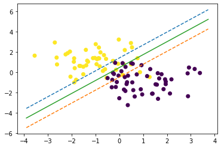

```python
X, y = generate_nonseperable_dataset(100)
result, w, b, zeta = solve_soft_margin_svm(X, y)
visualize_svm_classifier(X, y, w, b)
```

## Nonlinear Classifiers

### The Lagrangian Dual

The lagrangian dual of the soft-margin optimization problem is given below.

$$ \begin{equation} \begin{aligned} \max_{\alpha} \quad & \sum_{i=1}^m \alpha_i - \frac{1}{2}\sum_{i=1}^m \sum_{j=1}^m y_i \alpha_i (x_i^Tx_j) y_j \alpha_j \\ \text{s.t.} \quad & \sum_{i=1}^m \alpha_i y_i = 0 \\ & 0 \leq \alpha_i \leq \frac{1}{2m\lambda}, \quad i \in \{1,...,m\} \\ \end{aligned} \end{equation} $$

Using a training example that lies exactly on the margin, denoted $(x_s, y_s)$, we can recover the original parameters $w$ and $b$ from the solution to the dual problem. Note that $0 < \alpha_i < \frac{1}{2n\lambda}$ if and only if $x_i$ lies exactly on the margin. If $x_i$ lies outside the margin, then $\alpha_i = 0$ and if $x_i$ lies within the margin, then $\alpha_i = \frac{1}{2n\lambda}$.

$$ \begin{aligned} w &= \sum_{i=1}^m \alpha_i y_i x_i \\ b &= y_s - w^T x_s \end{aligned} $$

### The Kernel Trick

In order to generate a classifier with a nonlinear decision boundary, we can introduce a feature mapping $\phi: \mathbb{R}^n \rightarrow \mathbb{R}^d$. For any $x \in \mathbb{R}^n$, $\phi(x)$ is a high-dimensional feature vector with entries that can be nonlinear functions of the entries of $x$. When given such a feature mapping explicitly, all that is required is to replace $x$ with $\phi(x)$ in the optimization problem (for training) and in the classifier expression (for inference).

However, we often prefer to use a kernel function $K : (\mathbb{R}^n, \mathbb{R}^n) \rightarrow \mathbb{R}$ instead of explicit feature mappings. The kernel function can be thought of as a condensed representation of some (possibly infinite-dimensional) *implicit* feature mapping. It accepts vectors $x_a \in \mathbb{R}^n$ and $x_b \in \mathbb{R}^n$ and produces a scalar that can be interpreted as $\phi(x_a)^T\phi(x_b)$. Common kernels include the polynomial kernel (defined by $K(x_a, x_b) = (x_a^Tx_b + 1)^d$ for some $d > 0$) and the gaussian radial basis function kernel (defined by $K(x_a, x_b) = e^{-\lambda ||x_a - x_b||^2}$ for some $\lambda > 0$).

When using a kernel function, the lagrangian dual problem comes in handy. Because this formulation of the optimization problem only depends on the inner products of feature vectors, we can express its objective in terms of the kernel function alone. First, we define a kernel matrix $M \in \mathbb{R}^{m \times m}$ that contains the inner products involved in training.

$$ M = \begin{bmatrix} y_1^2 K(x_1,x_1) & ... & y_1 y_m K(x_1, x_m) \\ \vdots & \ddots & \vdots \\ y_m y_1 K(x_m, x_1) & ... & y_m^2 K(x_m, x_m) \end{bmatrix} $$

Then, the objective function can be expressed as follows.

$$ \begin{aligned} \min_{\alpha} \quad & \frac{1}{2}\alpha^TM\alpha - \sum_{i=1}^m \alpha_i \end{aligned} $$

Finally, the inference rule is given as follows, for some $(x_s, y_s)$ on the margin.

$$ b = y_s - \sum_{i=1}^m \alpha_i y_i K(x_i,x_s) $$$$ \begin{equation} f(x) = \begin{cases} +1 \quad & \sum_{i=1}^m \alpha_i y_i K(x_i,x) + b > 0 \\ -1 \quad & \sum_{i=1}^m \alpha_i y_i K(x_i,x) + b < 0 \\ \end{cases} \end{equation} $$

The below code generates a nonlinear dataset, trains an SVM with a radial basis function kernel by solving the above optimization problem, and produces a visualization of the nonlinear decision boundary.

```python
epsilon = 10e-7


def generate_nonlinear_dataset(n_samples):
    np.random.seed(seed=0)
    theta = np.linspace(0, 2 * np.pi, n_samples // 2)
    X_pos = np.vstack(
        (
            np.cos(theta) + np.random.normal(0, 0.2, n_samples // 2),
            np.sin(theta) + np.random.normal(0, 0.2, n_samples // 2),
        )
    ).T
    X_neg = np.vstack(
        (
            2 * np.cos(theta) + np.random.normal(0, 0.2, n_samples // 2),
            2 * np.sin(theta) + np.random.normal(0, 0.2, n_samples // 2),
        )
    ).T
    y = np.hstack((np.ones(n_samples // 2), -np.ones(n_samples // 2)))
    X = np.vstack((X_pos, X_neg))
    return X, y


def visualize_nonlinear_boundary(
    X, y, scaled, kernel_function, margin_idx, nnz_indices
):
    def compute_kernel_sum(z):
        return sum((scaled[i] * kernel_function(X[i, :], z)) for i in nnz_indices)

    b = y[margin_idx] - compute_kernel_sum(X[margin_idx, :])
    t0 = np.linspace(np.min(X[:, 0]), np.max(X[:, 0]), 100)
    t1 = np.linspace(np.min(X[:, 1]), np.max(X[:, 1]), 100)

    labels = []
    coords_x0 = []
    coords_x1 = []
    for p0 in tqdm.tqdm(t0):
        for p1 in t1:
            coords_x0.append(p0)
            coords_x1.append(p1)
            prediction = compute_kernel_sum(np.array([p0, p1])) + b
            if prediction > 1:
                labels.append(+1)
            elif prediction > -1:
                labels.append(0)
            else:
                labels.append(-1)

    fig, axes = plt.subplots(nrows=1, ncols=2, figsize=(10, 4))
    axes[0].scatter(X[:, 0], X[:, 1], c=y)
    axes[1].scatter(coords_x0, coords_x1, c=labels)
    plt.show()


def find_margin_index(bound, alpha):
    for i in range(X.shape[0]):
        if epsilon < alpha[i] < (bound - epsilon):
            return i
    return -1


def find_nnz_indices(alpha):
    nnz_indices = []
    for i in range(X.shape[0]):
        if epsilon < alpha[i]:
            nnz_indices.append(i)
    return nnz_indices


def solve_dual_problem(X, y, kernel_function, reg=0.0001):

    bound = 1 / (2 * X.shape[0] * reg)
    K = np.zeros((X.shape[0], X.shape[0]))
    for i in range(X.shape[0]):
        for j in range(X.shape[0]):
            K[i, j] = y[i] * y[j] * kernel_function(X[i, :], X[j, :])

    alpha = cp.Variable(X.shape[0])
    objective = cp.Minimize(0.5 * cp.quad_form(alpha, K) - cp.sum(alpha))
    constraints = [0 <= alpha, alpha <= bound, cp.sum(alpha @ y) == 0]
    prob = cp.Problem(objective, constraints)
    result = prob.solve(solver='ECOS_BB')
    margin_idx = find_margin_index(bound, alpha.value)
    nnz_indices = find_nnz_indices(alpha.value)
    scaled = np.multiply(y, alpha.value)
    return scaled, margin_idx, nnz_indices
```

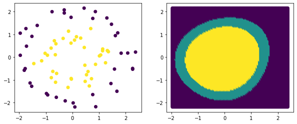

```python
X, y = generate_nonlinear_dataset(75)
kernel_function = lambda x_a, x_b: np.exp(-0.1 * np.linalg.norm(x_a - x_b) ** 2)
scaled, margin_idx, nnz_indices = solve_dual_problem(X, y, kernel_function)
visualize_nonlinear_boundary(X, y, scaled, kernel_function, margin_idx, nnz_indices)
```